# Module 6 Project Report

Jaan Selod

2023-10-21

# Introduction:

The paraphyletic clade of butterflies and moths forms the order Lepidoptera, described as representing a “superradiation” of 160,000 extant species (Kawahara et al. 2019). Because of this extensive radiation, lepidopterans play a multitude of ecological roles in most (if not all) terrestrial ecosystems (Duplouy and Hornett (2018)), and it is therefore argued that several factors (ranging from environment to sexual selection) influence morphology.

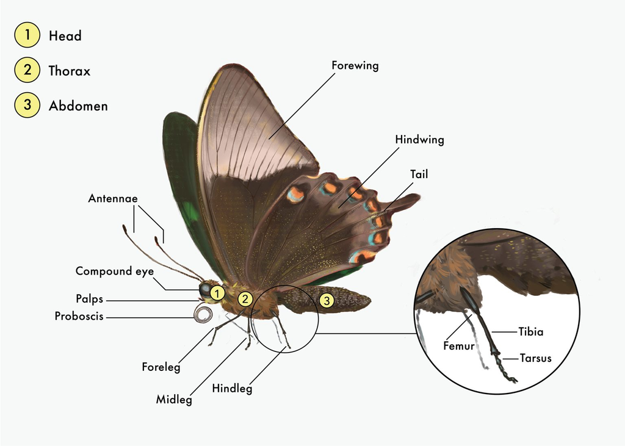

Figure 1: Butterfly Anatomy

Hindwings and forewings may not play the same role in flight. A study of powered flight without the hindwing revealed that lepidopterans could still fly without their hindwings, although not as fast and with less maneuverability (Jantzen and Eisner 2008). In fact, these authors concluded that the hindwings may contribute to survival, indicating the selection pressures between forewing and hindwing could differ. For example, since flight is conserved with the loss of the expanded hindwing, there may be a stabilizing selection pressure from the demands of flight. On the other hand, the hindwing may be under selection pressures related to predator avoidance (maneuverability and zigzaging behaviors) or even sexual selection.

Our study examines this relationship between wings. We seek to answer whether the rates of wing-shape evolution are different between the hind- and forewing, and if so, by how much. Additional questions include: Are hind- and forewing shapes correlated? What inferences can we make based on shape correlations and flight control?

# Methods:

A morphometric approach was used to conduct the project. Images of various species and specimens from Lepidoptera were obtained from Dr. Kenaley’s work. Using the analysis program FIJI, outlines of both forewings and hindwings were traced digitally and fitted with a spline to produced lists of xy_coordinates for each specimen and wingtype. Shape analysis was outline-based. A generalized Procrustes transformation was used to superimpose and scale each object (outline) to minimize variability from arbitrary size differences. Next, Elliptical Fourier Analysis (EFA) was used to describe the shapes (outlines) in the dataset, followed by Principal Components Analysis to find the major types of variance in the data. Comparative analysis was conducted from the first two principal components for each wing type, annotated with species information. The ‘non-censored test’ method from O’Meara et al. (2006) was used in order to calculate the likelihood of evolutionary rates, using an estimation of of an ancestral trait under Brownian motion, across the entire phylogenetic tree of Lepidoptera (also obtained from Dr. Kenaley). Finally, shape evolution correlation was analyzed using phylogenetic independent contrasts (PIC) to regress the first and second principal components for forewings versus hindwings.